# Tutorial 2: Descriptive statistics

Forschungspraktikum I und II: Vergleichende Sozialforschung mit Mehrebenenmodellen in R

Dr. Christian Czymara (Sociology with Focus on Quantitative Methods for Social Research, Goethe University Frankfurt)

In this tutorial, we are interested in the relationship between religion and happiness, using the first wave of the European Social Survey (ESS).

## 1. Importing data

Last session, we could simply load the data into our environment using the `load()` function. This worked because the data were stored in R’s own .RData format. However, to this day I’m not aware of a single survey program (or other data source) that offers downloads in this format. Thus, we will have to *import* some other data format to R. In this case, we have the data available in Stata’s .dta format (as provided through the ESS website). To import .dta-files is we need a new package: `haven`. Install (`install.packages("haven")`) and load (`library(haven)`) this package.

```r
setwd("C:/Users/czymara.local/PowerFolders/teaching/FoP HLM/_R/02_research_process")
```

[output not shown]

```r
# install package (if not already installed), then load package
if(!require(haven)){
    install.packages("haven")
    library(haven)
  }
```

After having loaded the `haven` package, we can use its `read_dta()`-function. Use it to import the ess2002.dta file by assigning the data to an object called `ESS02`.

```r
ESS02 <- read_dta("ess2002.dta")
```

## 2. Data inspection

### a) Overview

In total, how many respondents are in our data set? How many variables?

```r
nrow(ESS02) # respondents
```

```
## [1] 42359
```

```r
ncol(ESS02) # variables
```

```
## [1] 565
```

### b) Religion

What was the most popular religion in this wave of the ESS?

```r
# show table
table(ESS02$rlgdnm)
```

```
##
##     1     2     3     4     5     6     7     8
## 13801  6706  2528   749  1356   789   123   169
```

```r
# which value has which label?
attr(ESS02$rlgdnm, "labels")
```

```
##                roman catholic                    protestant
##                             1                             2
##              eastern orthodox  other christian denomination
##                             3                             4
##                        jewish                         islam
##                             5                             6
##             eastern religions other non-christian religions
##                             7                             8
##                not applicable                       refusal
##                            66                            77
##                     no answer
##                            99
```

```r
# table with labels
table(as_factor(ESS02$rlgdnm, levels="label")) # absolute
```

```
##
##                roman catholic                    protestant
##                         13801                          6706
##              eastern orthodox  other christian denomination
##                          2528                           749
##                        jewish                         islam
##                          1356                           789
##             eastern religions other non-christian religions
##                           123                           169
##                not applicable                       refusal
##                             0                             0
##                     no answer
##                             0
```

```r
prop.table(table(as_factor(ESS02$rlgdnm, levels="label"))) # relative
```

```
##
##                roman catholic                    protestant
##                   0.526333855                   0.255749209
##              eastern orthodox  other christian denomination
##                   0.096411273                   0.028564891
##                        jewish                         islam
##                   0.051714275                   0.030090386
##             eastern religions other non-christian religions
##                   0.004690897                   0.006445216
##                not applicable                       refusal
##                   0.000000000                   0.000000000
##                     no answer
##                   0.000000000
```

You will see that R will display numeric values by default (e.g.: “roman catholic” is 1), which isn’t very helpful in this case. `sjlabelled` is a package designed to work with labelled data. Install and load `sjlabelled`. Then use its `to_character()`-function to generate a character variable `rlgdnm_lbl` that is based on the original `rlgdnm` variable, but has its labels as (character-) values. Make a table with the `rlgdnm_lbl` variable.

```r
# install package (if not already installed), then load package
if(!require(sjlabelled)){
    install.packages("sjlabelled")
    library(sjlabelled)
  }

ESS02$rlgdnm_lbl <- to_character(ESS02$rlgdnm)

typeof(ESS02$rlgdnm_lbl)
```

```
## [1] "character"
```

```r
table(ESS02$rlgdnm_lbl)
```

```
##
##              eastern orthodox             eastern religions
##                          2528                           123
##                         islam                        jewish
##                           789                          1356
##  other christian denomination other non-christian religions
##                           749                           169
##                    protestant                roman catholic
##                          6706                         13801
```

### c) Happiness per religious group

What is the average life satisfaction of the religious denominations? Hint: use the `aggregate()`-function. Would you say that this religion makes its followers happier than others?

```r
# assign table to object
lifesat_rel_table <- aggregate(ESS02$stflife,
          list(ESS02$rlgdnm_lbl),
          mean,
          na.rm = TRUE)

lifesat_rel_table
```

```
##                         Group.1        x
## 1              eastern orthodox 6.302464
## 2             eastern religions 7.260163
## 3                         islam 6.139386
## 4                        jewish 6.796145
## 5  other christian denomination 7.387399
## 6 other non-christian religions 7.184524
## 7                    protestant 7.729378
## 8                roman catholic 6.902353
```

```r
# show in descending order
lifesat_rel_table[order(lifesat_rel_table$x, decreasing = T), ]
```

```
##                         Group.1        x
## 7                    protestant 7.729378
## 5  other christian denomination 7.387399
## 2             eastern religions 7.260163
## 6 other non-christian religions 7.184524
## 8                roman catholic 6.902353
## 4                        jewish 6.796145
## 1              eastern orthodox 6.302464
## 3                         islam 6.139386
```

```r
# alterantive for table
aggregate(stflife ~ rlgdnm_lbl, data = ESS02, mean)
```

```
##                      rlgdnm_lbl  stflife
## 1              eastern orthodox 6.302464
## 2             eastern religions 7.260163
## 3                         islam 6.139386
## 4                        jewish 6.796145
## 5  other christian denomination 7.387399
## 6 other non-christian religions 7.184524
## 7                    protestant 7.729378
## 8                roman catholic 6.902353
```

## 3. Plotting

Let’s plot this finding. What we want is a bar chart with the mean values of life satisfaction for each religious group. For this, we need the `tidyverse`, as we will work with its `ggplot2`-package. `ggplot2` might be *the* most powerful tool for data vizualization, as it can plot [basically everything](https://github.com/rstudio/cheatsheets/blob/main/data-visualization-2.1.pdf). The basis for this is the initial plot, where you define the *data*, *x* and *y* in the following way: `ggplot(data, aes(x, y))`. Adapt this code to plot `rlgdnm_lbl` as our x and `stflife` as y. If you need help, check https://ggplot2.tidyverse.org/ or https://www.r-graph-gallery.com/ggplot2-package.html

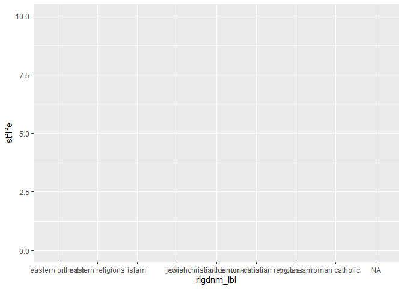

```r
# load tidyverse
if(!require(tidyverse)){
    install.packages("tidyverse")
    library(tidyverse)
}

ggplot(ESS02, aes(x = rlgdnm_lbl,
           y = stflife))
```

You will see that this will create a two-dimensional plot, with an x-axis and a y-axis However, it won’t show any data. This is because we haven’t told `ggplot2` yet how to display the data (e.g., density plot, line chart, scatter plot, histogram etc.). What we want here is a *bar chart*, so we add a new layer (`+`) to our plot: `geom_bar()` (see [here](https://www.r-graph-gallery.com/218-basic-barplots-with-ggplot2.html)). By default, `geom_bar()` will show the number of cases in each group of x. However, we want the mean values of y for each group of x. This can be achieved using `geom_bar(stat = "summary", fun = "mean")`. Create the bar chart showing mean values of life satisfaction by religion.

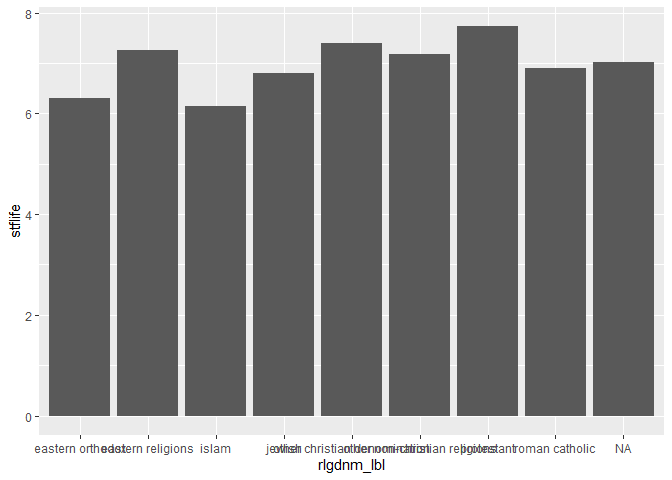

```r
# Distribution of life satisfaction
ggplot(ESS02, aes(x = rlgdnm_lbl,
           y = stflife)) +
  geom_bar(stat = "summary",
           fun = "mean")
```

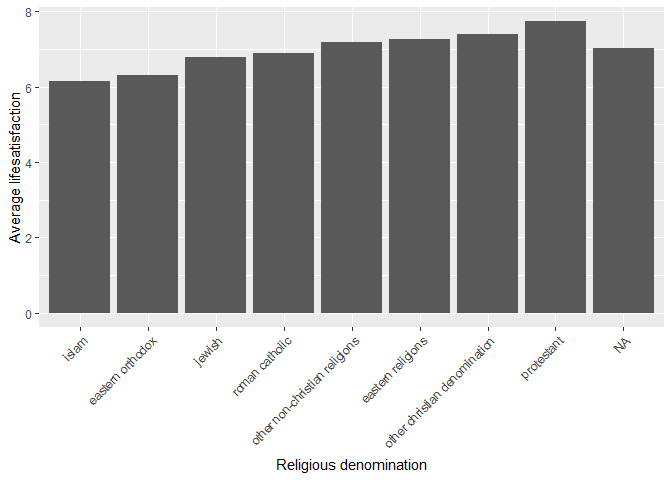

```r
# Nicer:
ESS02 %>%
  drop_na(stflife) %>% # need to drop missings for ordering on y
  ggplot(aes(x =  reorder(rlgdnm_lbl, stflife, mean), # order on y
           y = stflife)) +
  geom_bar(stat = "summary",
           fun = "mean") +
  labs(y = "Average lifesatisfaction", x = "Religious denomination") +
  theme(axis.text.x = element_text(angle = 45,
                                   hjust=1))
```

## 4. Comparing countries

### a) Table

Now let’s take a cross-national perspective. What is the distribution of the different denominations across countries? Show in a table.

```r
round(prop.table(table(ESS02$rlgdnm_lbl, ESS02$cntry), 2), 2)
```

```
##
##                                   AT   BE   CH   CZ   DE   DK   ES   FI FR   GB
##   eastern orthodox              0.01 0.00 0.01 0.00 0.01 0.00 0.00 0.01    0.00
##   eastern religions             0.01 0.01 0.00 0.00 0.01 0.01 0.00 0.00    0.03
##   islam                         0.02 0.04 0.01 0.00 0.04 0.03 0.01 0.00    0.04
##   jewish                        0.00 0.00 0.00 0.00 0.00 0.00 0.00 0.00    0.01
##   other christian denomination  0.02 0.02 0.01 0.03 0.03 0.01 0.01 0.02    0.04
##   other non-christian religions 0.00 0.01 0.01 0.01 0.00 0.00 0.00 0.00    0.01
##   protestant                    0.05 0.01 0.46 0.11 0.54 0.94 0.01 0.96    0.69
##   roman catholic                0.87 0.90 0.50 0.85 0.37 0.01 0.98 0.00    0.19
##
##                                   GR   HU   IE   IL   IT   LU   NL   NO   PL
##   eastern orthodox              0.96 0.00 0.00 0.00 0.00 0.01 0.00 0.00 0.01
##   eastern religions             0.00 0.00 0.00 0.00 0.00 0.01 0.01 0.01 0.00
##   islam                         0.03 0.00 0.00 0.20 0.00 0.02 0.04 0.02 0.00
##   jewish                        0.00 0.00 0.00 0.71 0.00 0.00 0.00 0.00 0.00
##   other christian denomination  0.00 0.02 0.01 0.00 0.01 0.23 0.10 0.04 0.00
##   other non-christian religions 0.00 0.01 0.00 0.04 0.00 0.00 0.00 0.02 0.00
##   protestant                    0.00 0.26 0.04 0.00 0.01 0.01 0.37 0.89 0.00
##   roman catholic                0.00 0.72 0.95 0.05 0.98 0.72 0.46 0.01 0.99
##
##                                   PT   SE   SI
##   eastern orthodox              0.00 0.02 0.02
##   eastern religions             0.00 0.01 0.00
##   islam                         0.00 0.04 0.02
##   jewish                        0.00 0.00 0.00
##   other christian denomination  0.02 0.04 0.00
##   other non-christian religions 0.00 0.01 0.00
##   protestant                    0.01 0.84 0.01
##   roman catholic                0.97 0.03 0.94
```

### b) Plot

Let’s plot this. We will again use `ggplot2`. This time we will not plot x against y, but we want a so-called *stacked* bar chart, where the full bar consists of the percentages that are stacked on top of each other (summing up to 1, see [Percent stacked barchart](https://www.r-graph-gallery.com/48-grouped-barplot-with-ggplot2.html)). Hence, we have to change the code to: `ggplot(aes(x = cntry, fill = rlgdnm_lbl))`. In addition, we have to change the code for the bar chart to: `geom_bar(position="fill")`. Create the bar chart with the religious groups stacked per country.

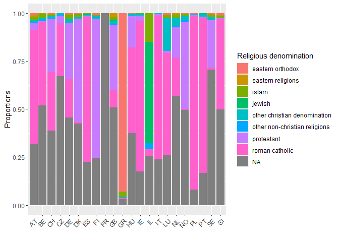

```r
# stacked bar chart
ESS02 %>%
  ggplot(aes(x = cntry,
           fill = rlgdnm_lbl)) +
  geom_bar(position="fill") +
  labs(y = "Proportions", x = "", fill = "Religious denomination") +
  theme(axis.text.x = element_text(angle = 45,
                                   hjust=1))
```

### c) Removing missing data

The large share of missing values in many countries is mostly because the question isn’t being asked to respondents who say they’re not religious. Can you plot the same bar chart without the missing values?

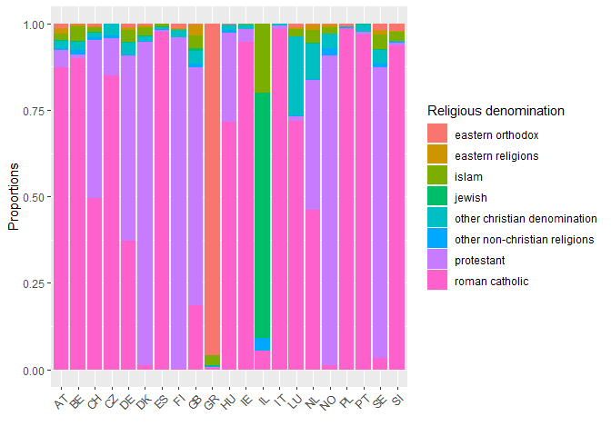

```r
# stacked bar chart
ESS02 %>%
  drop_na(rlgdnm_lbl) %>%
  ggplot(aes(x = cntry,
           fill = rlgdnm_lbl)) +
  geom_bar(position="fill") +
  labs(y = "Proportions", x = "", fill = "Religious denomination") +
  theme(axis.text.x = element_text(angle = 45,
                                   hjust=1))
```